# Développement de la méthode

Version française

Antoine Batigny & Guyliann Engels

2018-05-30

Abstract

Ce document a pour objectif de mettre en avant les multiples analyses réalisées avec l’autoanalyseur seal-AA3

# 1 Introduction

## 1.1 Prélèvement

Pour les analyses des nutiments minéraux, on prélève directement dans dans le flacon de prélèvement. Par contre, l’échantillonnage prélevé se fait en 2 étapes car il faut filtrer l’échantillon avant de l’analyser. Il est conseillé de filtrer l’eau avec un filtre de $10 \mu m$. Les prélèvements des éléments minéraux peuvent être stocké dans des échantillons en plastique. Par contre, les récipient en verre sont à privilégier les éléments organiques. Il est conseillé d’échantillonner 100ml alors que 1 ml est employé pour l’analyse.

Les échantillons qui ne peuvent être dosé le jour même doivent être congelé. Lors de la préparation des échantillons pour analyse des règles strictes doivent être suivie.

Durant la décongélation :

- maintenir les flacons bouchés et debout
- éviter toute surchauffe (laisser décongeler à température ambiante, placer au réfrigirateur la veuille suivi d’un période à température ambiante)
- protéger de la lumière
- agiter régulièrement

Une fois décongélé :

- maintenir les échantillons au frais (10°C)et à l’abris de la lumière
  - réduit la dégradation biologique
  - n’affecte pas l’analyse

## 1.2 Dosage des nitrites

Le dosage des nitrites repose sur la réaction de Griess (adapté à l’eau de mer Benschneider & Robinson). Les nitrites réagissent avec sulfanilamide puis avec le N-naphtyl-éthylènediamie en milieu acide.

La limite de détection est de $1 nmol/L$

## 1.3 Dosage des nitrates

Le dosage des nitrates se fait via la réduction en nitrite sur un milieu hétérogène par contact au cadmium. Cette méthode dose donc la somme des nitrites et des nitrates. De plus, lors de la réduction des vapeurs d’ammoniac.

La limite de détection est de $10\mumol/L$

## 1.4 Dosage des ammoniums

En milieu basique, la réaction de berthelot va permettre de doser à 630 nm.

Le dosage va mesurer le $NH_3$ et le $NH_4^+$

## 1.5 Dosage des phosphates

Le dosage se base sur la méthode de Murphy & Riley 1962. En milieu acide, le phosphate réagit avec molybdate en présence d’antimoine afin de former le complexe phosphomolybdique qui est réduit par acide ascorbique.

La limite de détection est de $1 nmol/L$

## 1.6 Dosage de l’azote total dissous

L’azote total dissous comprend l’ensemble des formes azotées minérales et organiques à l’exception du $N_2$ (particule dans de l’eau filtrée avec des mailles de $0.5 \mu m$). Les molécules organiques dissoutes sont peu affectée par la dégradation bactérienne. L’azote total dissous peut de ce fait donner une fausse information de l’azote disponible.

$$NID (azote \ inorganique \ dissous) = nitrate + nitrite + ammonium$$

$$NOD (azote \ organique \ dissous)$$

$$NTD (azote \ total \ dissous) = NID + NOD$$

Le NOD est converti afin d’être doser comme des composés inorganiques.

La conservation des échantillons se fait par -25°C.

## 1.7 Dosage du phosphore total dissous

Les molécules organiques dissoutes ne sont pas entièrement affectée par la dégradation bactérienne. Le phosphore total dissous peut de ce fait donner une fausse information de phosphore disponible.

La conservation des échantillons se fait par -25°C.
$$PID = \ \sim phosphate$$

$$POD (phospore \ organique \ dissous)$$

$$PTD (phosphore \ total \ dissous) = PID + POD$$
# Expérience de mise au point

## 1.8 Reproductibilité 1 : Décembre 2017

### 1.8.1 Protocole

L’une des premières questions est de savoir si les analyses sont reproductibles. Pour ce faire, le même échantillons est dosé 10 fois.

### 1.8.3 Ions nitrates

A nouveau, les concentrations les plus faibles ont des coefficient de variation plus important.

### 1.8.7 Ions nitrites

### 1.8.8 Conclusion et perspectives

L’interrogation la plus importante sur cette expérience est le dosage moitié moins important du $NO_2$ lors du dosage de l’azote total.

## 1.9 Dégradation au cours du temps 1

### 1.9.1 Protocole

L’un des éléments influencant la précision de la mesure est le temps. Pour ce faire, des échantillons sont dosé à plusieurs reprise au cours du temps (sur un délais de 45 minutes) afin d’observer cette dégradation.

### 1.10.1 Protocole

Les expériences précédentes ont montrés que les calibrants $NO_2$ ne sont pas entièrement détecté lors de dosage de l’azote total. Il en est de même lors du dosage du phosphore total par rapport aux calibrants $PO_4$.

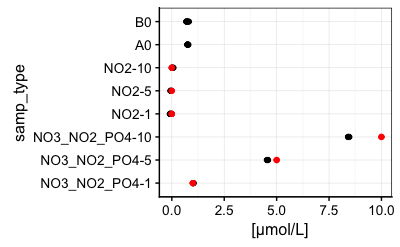

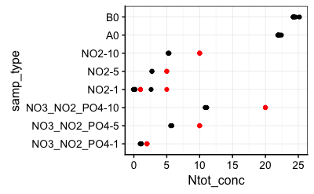

### 1.11.1 Phosphore total

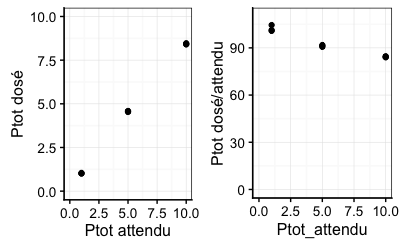

On observe que plus l’échantillon est important plus l’erreur du le dosage augmente.

### 1.11.2 Azote total

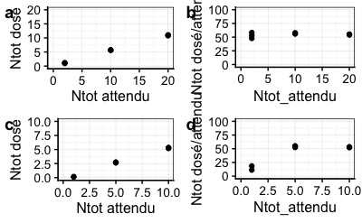

# 2 Utilisation des méthodes Ifremer

Les méthodes ifremer sont des versions optimisées des méthodes SEAL plus anciennes et génériques. Les eaux peu salées engendrent une trainée du signal avec un effet de carry-over.

## 2.1 Prélèvements, échantillonnage, filtration

On conseille d’employer une pré-filtration avec un filtre de $10\mu m$ afin d’obtenir un volume de $100ml$ (bien que trop important pour une analyse, le volume peut réduire l’effet de contamination. Les flacons d’échantillonnage en plastiques sont suffisants pour les éléments inorganiques. Il est préférable d’employer des flacons en verre pour la matière organique dissoute.

Les flacons doivent être rincé à l’$HCl$ et les flacons en verre doivent être pyrolysés à $500 C°$

## 2.2 Les particularité